# Homework_3

Emily Ogden

January 27, 2020

# Part 1

```r
lake=read.csv("Killarney.csv")
attach(lake)
```

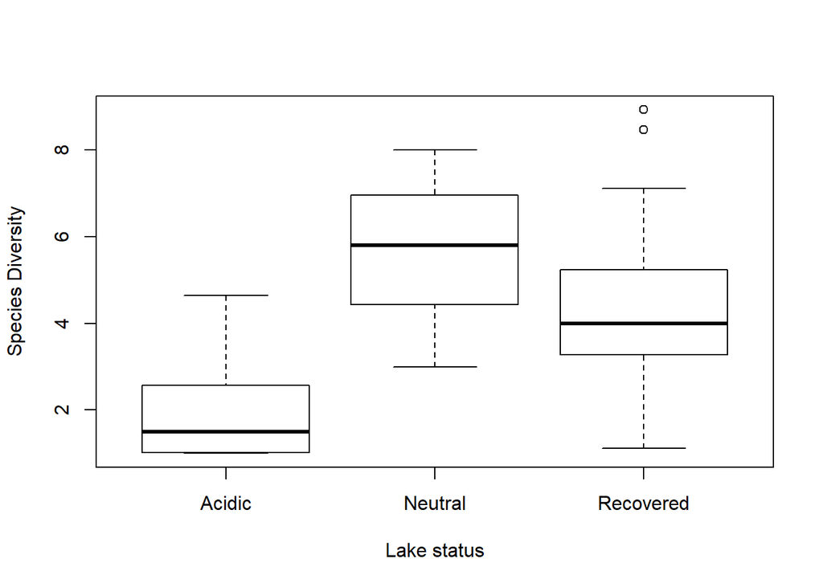

```r
boxplot(Diversity~status, xlab="Lake status", ylab = "Species Diversity")
```

Acidic lakes seem to have a lower species diversity than the neutral and recovered lakes.  
3.

```r
mod1=aov(Diversity~status)
summary(mod1)
```

```
##             Df Sum Sq Mean Sq F value   Pr(>F)
## status       2  97.41   48.70   16.41 5.43e-06 ***
## Residuals   42 124.68    2.97
## ---
## Signif. codes:  0 '***' 0.001 '**' 0.01 '*' 0.05 '.' 0.1 ' ' 1
```

4. $$H_0:\mu_{acid}=\mu_{neutral}=\mu_{recovered}$$
5. $$F_{obs}=16.41$$
   $$p-value=5.43*10^{-6}$$
6. At least one of the lake types is different than the other types based on the p-value that is less than 0.05.

```r
TukeyHSD(mod1)
```

```
##   Tukey multiple comparisons of means
##     95% family-wise confidence level
##
## Fit: aov(formula = Diversity ~ status)
##
## $status
##                        diff       lwr      upr     p adj
## Neutral-Acidic     3.603068  1.874854 5.331282 0.0000253
## Recovered-Acidic   2.418485  1.016843 3.820127 0.0004023
## Recovered-Neutral -1.184583 -3.017179 0.648012 0.2695118
```

8. There is a significant difference between Neutral and acidic lake types (p=0.00002) and between recovered and acidic lake types(0.0004).

```r
library(car)
shapiro.test(mod1$residuals)
```

```
##
##  Shapiro-Wilk normality test
##
## data:  mod1$residuals
## W = 0.93501, p-value = 0.01415
```

```r
leveneTest(mod1)
```

```
## Levene's Test for Homogeneity of Variance (center = median)
##       Df F value Pr(>F)
## group  2  0.9977 0.3773
##       42
```

Since p<0.05 for the Shapiro-Wilk test, we reject the null hypothesis that the residuals are normally distributed. However, for the Levene’s test the p-value was greater than 0.05. Therefore, we fail to reject the null hypothesis that the variences are equale. The data does not meet the assumption that the residuals of the model are normally distributed, but does meet the assumption of equale variance within groups.  
10.a)

```r
cancer=read.csv("esoph.csv")
attach(cancer)
mod2=aov(ncases~Alcohol*Tobacco)
summary(mod2)
```

```
##                 Df Sum Sq Mean Sq F value Pr(>F)
## Alcohol          3   46.9  15.624   2.085  0.110
## Tobacco          3   41.5  13.846   1.848  0.146
## Alcohol:Tobacco  9   31.5   3.501   0.467  0.892
## Residuals       72  539.5   7.494
```

2. Based on the results from the ANOVA table, there is no significant effect of Alcohol (p=0.110), Tobacco (p=0.146), or the interaction (p=0.892) between the two on the number of cancer cases.  
   11.a)

```r
mod3=aov(ncases~Age*Tobacco)
summary(mod3)
```

```
##             Df Sum Sq Mean Sq F value  Pr(>F)
## Age          5 261.20   52.24  12.826 1.2e-08 ***
## Tobacco      3  52.97   17.66   4.335 0.00763 **
## Age:Tobacco 15  84.62    5.64   1.385 0.18215
## Residuals   64 260.67    4.07
## ---
## Signif. codes:  0 '***' 0.001 '**' 0.01 '*' 0.05 '.' 0.1 ' ' 1
```

```r
TukeyHSD(mod3)
```

```
##   Tukey multiple comparisons of means
##     95% family-wise confidence level
##
## Fit: aov(formula = ncases ~ Age * Tobacco)
##
## $Age
##                   diff        lwr        upr     p adj
## 35-44-25-34  0.5333333 -1.6316077  2.6982744 0.9783189
## 45-54-25-34  2.8083333  0.6774880  4.9391787 0.0033564
## 55-64-25-34  4.6833333  2.5524880  6.8141787 0.0000002
## 65-74-25-34  3.6000000  1.4350590  5.7649410 0.0001028
## 75+-25-34    1.1151515 -1.2383875  3.4686905 0.7316114
## 45-54-35-44  2.2750000  0.1441547  4.4058453 0.0296780
## 55-64-35-44  4.1500000  2.0191547  6.2808453 0.0000044
## 65-74-35-44  3.0666667  0.9017256  5.2316077 0.0013005
## 75+-35-44    0.5818182 -1.7717208  2.9353572 0.9779839
## 55-64-45-54  1.8750000 -0.2211951  3.9711951 0.1053407
## 65-74-45-54  0.7916667 -1.3391787  2.9225120 0.8830192
## 75+-45-54   -1.6931818 -4.0153959  0.6290322 0.2794932
## 65-74-55-64 -1.0833333 -3.2141787  1.0475120 0.6695191
## 75+-55-64   -3.5681818 -5.8903959 -1.2459678 0.0003880
## 75+-65-74   -2.4848485 -4.8383875 -0.1313095 0.0325950
##
## $Tobacco
##                       diff       lwr        upr     p adj
## 10-19-0-9g/day -0.83333333 -2.370109  0.7034420 0.4853668
## 20-29-0-9g/day -1.85739899 -3.469183 -0.2456155 0.0175826
## 30+-0-9g/day   -1.80648990 -3.418273 -0.1947064 0.0220542
## 20-29-10-19    -1.02406566 -2.635849  0.5877179 0.3446841
## 30+-10-19      -0.97315657 -2.584940  0.6386270 0.3900235
## 30+-20-29       0.05090909 -1.632544  1.7343621 0.9998160
##
## $`Age:Tobacco`
##                                        diff          lwr         upr     p adj
## 35-44:0-9g/day-25-34:0-9g/day  5.000000e-01  -4.92250361  5.92250361 1.0000000
## 45-54:0-9g/day-25-34:0-9g/day  3.500000e+00  -1.92250361  8.92250361 0.7044917
## 55-64:0-9g/day-25-34:0-9g/day  6.250000e+00   0.82749639 11.67250361 0.0086982
## 65-74:0-9g/day-25-34:0-9g/day  7.750000e+00   2.32749639 13.17250361 0.0002200
## 75+:0-9g/day-25-34:0-9g/day    1.500000e+00  -3.92250361  6.92250361 0.9999909
## 25-34:10-19-25-34:0-9g/day     2.500000e-01  -5.17250361  5.67250361 1.0000000
```

[output cut: 255 more lines]

```
## 35-44:30+-25-34:30+            1.017704e-16  -5.85697331  5.85697331 1.0000000
## 45-54:30+-25-34:30+            2.750000e+00  -2.67250361  8.17250361 0.9536697
## 55-64:30+-25-34:30+            4.000000e+00  -1.42250361  9.42250361 0.4540368
## 65-74:30+-25-34:30+            6.666667e-01  -5.19030664  6.52363997 1.0000000
## 75+:30+-25-34:30+              1.000000e+00  -5.64118349  7.64118349 1.0000000
## 45-54:30+-35-44:30+            2.750000e+00  -3.10697331  8.60697331 0.9791234
## 55-64:30+-35-44:30+            4.000000e+00  -1.85697331  9.85697331 0.6036644
## 65-74:30+-35-44:30+            6.666667e-01  -5.59470117  6.92803451 1.0000000
## 75+:30+-35-44:30+              1.000000e+00  -6.00042206  8.00042206 1.0000000
## 55-64:30+-45-54:30+            1.250000e+00  -4.17250361  6.67250361 0.9999997
## 65-74:30+-45-54:30+           -2.083333e+00  -7.94030664  3.77363997 0.9994407
## 75+:30+-45-54:30+             -1.750000e+00  -8.39118349  4.89118349 0.9999962
## 65-74:30+-55-64:30+           -3.333333e+00  -9.19030664  2.52363997 0.8730024
## 75+:30+-55-64:30+             -3.000000e+00  -9.64118349  3.64118349 0.9864955
## 75+:30+-65-74:30+              3.333333e-01  -6.66708873  7.33375539 1.0000000
```

```r
mod4=aov(ncases~Age*Alcohol)
summary(mod4)
```

```
##             Df Sum Sq Mean Sq F value   Pr(>F)
## Age          5  261.2   52.24  14.048 2.89e-09 ***
## Alcohol      3   52.7   17.57   4.723  0.00486 **
## Age:Alcohol 15  107.6    7.17   1.928  0.03633 *
## Residuals   64  238.0    3.72
## ---
## Signif. codes:  0 '***' 0.001 '**' 0.01 '*' 0.05 '.' 0.1 ' ' 1
```

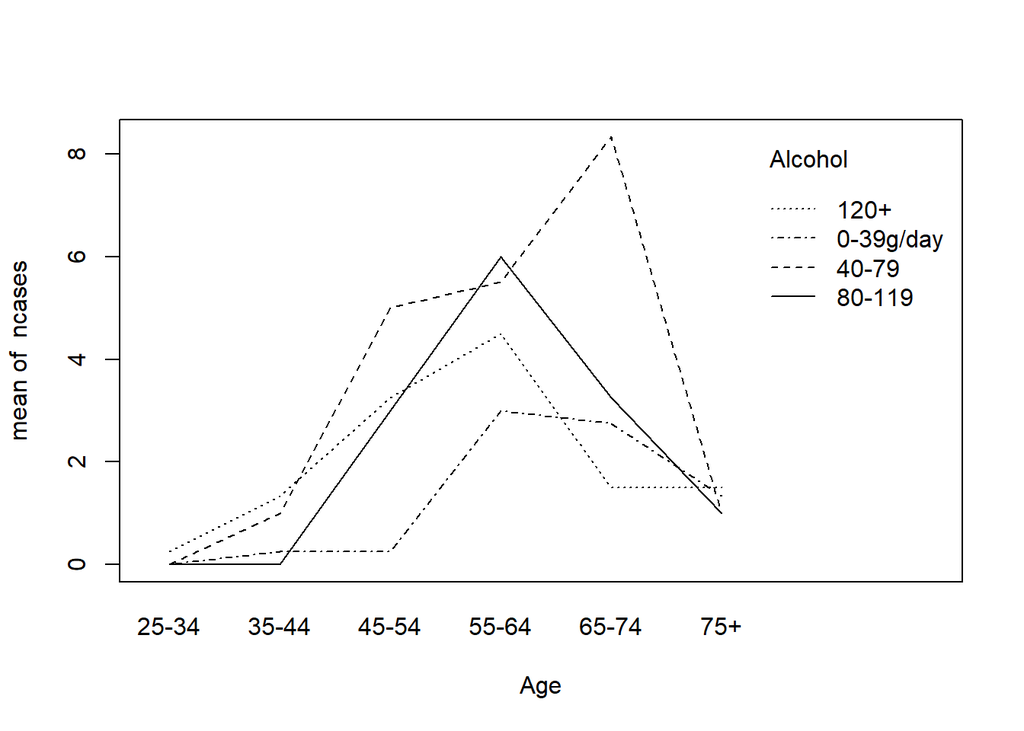

```r
interaction.plot(Age,Alcohol,ncases,legend = T)
```

c)  
Based on the results from the ANOVA table and the interaction plot, there is evidence to suggest that the interaction between age and alcohol is significant (p=0.0363), which suggests that the effect of alcohol on the mean number of cancer cases is dependent on age group. The overall effect of age on the mean number of cancer cases increases with age until approximately age 55. Consuming 40-79 g/day of alcohol has the greatest effect on mean number of cancer cases, while consuming 0-39 g/day had the least effect on mean number of cancer cases.

# Part 2

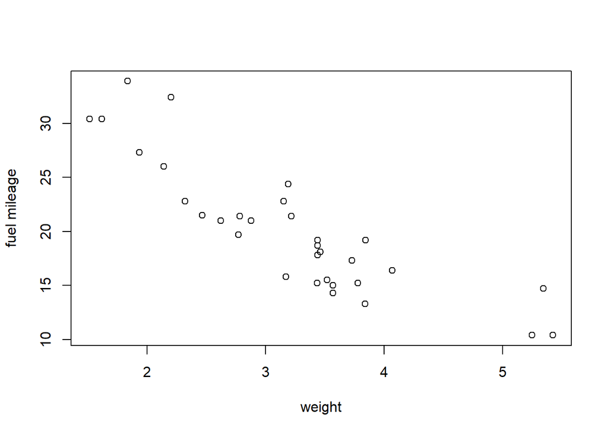

```r
View(mtcars)
plot(mtcars$wt,mtcars$mpg,xlab = "weight",ylab="fuel mileage")
```

Based on the scatterplot it appears that weight and fuel mileage are negatively associated.  
b)

```r
mod5=lm(mtcars$mpg~mtcars$wt)
summary(mod5)
```

```
##
## Call:
## lm(formula = mtcars$mpg ~ mtcars$wt)
##
## Residuals:
##     Min      1Q  Median      3Q     Max
## -4.5432 -2.3647 -0.1252  1.4096  6.8727
##
## Coefficients:
##             Estimate Std. Error t value Pr(>|t|)
## (Intercept)  37.2851     1.8776  19.858  < 2e-16 ***
## mtcars$wt    -5.3445     0.5591  -9.559 1.29e-10 ***
## ---
## Signif. codes:  0 '***' 0.001 '**' 0.01 '*' 0.05 '.' 0.1 ' ' 1
##
## Residual standard error: 3.046 on 30 degrees of freedom
## Multiple R-squared:  0.7528, Adjusted R-squared:  0.7446
## F-statistic: 91.38 on 1 and 30 DF,  p-value: 1.294e-10
```

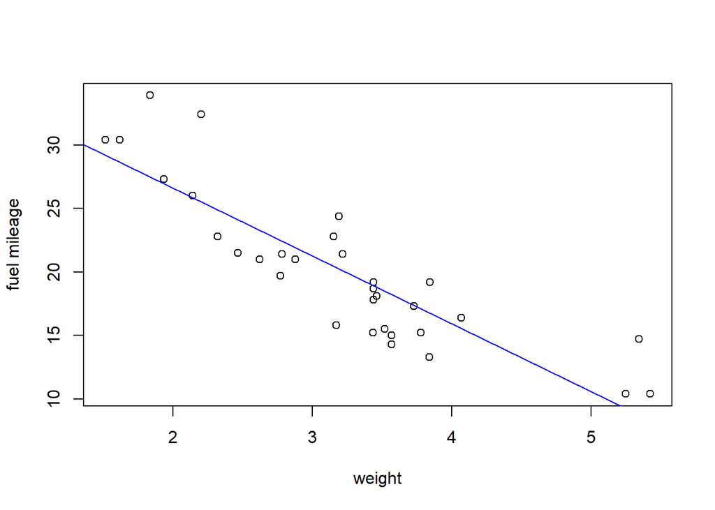

```r
plot(mtcars$wt,mtcars$mpg,xlab = "weight",ylab="fuel mileage")
abline(mod5,col="blue")
```

$$y=-5.34x+37.28$$
d)
Based on the linear model, there is evidence to suggest that gas mileage is negatively related to car weight (p=1.29e-10).
14. a)

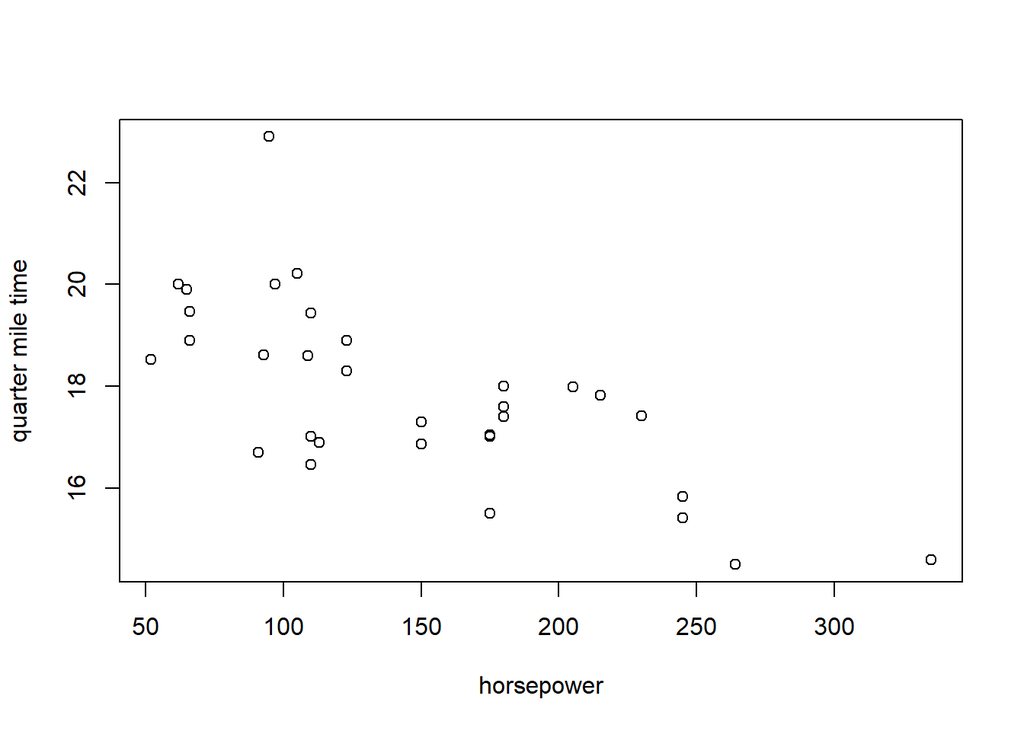

```r
plot(mtcars$hp,mtcars$qsec, xlab = "horsepower", ylab="quarter mile time")
```

Based on the scatterplot it seems that quarter mile time is negatively associated with horsepower.  
b)

```r
mod6=lm(mtcars$qsec~mtcars$hp)
summary(mod6)
```

```
##
## Call:
## lm(formula = mtcars$qsec ~ mtcars$hp)
##
## Residuals:
##     Min      1Q  Median      3Q     Max
## -2.1766 -0.6975  0.0348  0.6520  4.0972
##
## Coefficients:
##              Estimate Std. Error t value Pr(>|t|)
## (Intercept) 20.556354   0.542424  37.897  < 2e-16 ***
## mtcars$hp   -0.018458   0.003359  -5.495 5.77e-06 ***
## ---
## Signif. codes:  0 '***' 0.001 '**' 0.01 '*' 0.05 '.' 0.1 ' ' 1
##
## Residual standard error: 1.282 on 30 degrees of freedom
## Multiple R-squared:  0.5016, Adjusted R-squared:  0.485
## F-statistic: 30.19 on 1 and 30 DF,  p-value: 5.766e-06
```

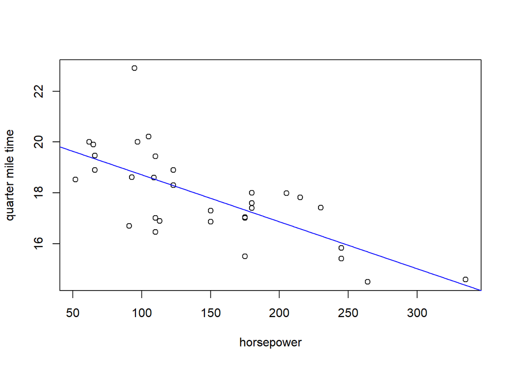

```r
plot(mtcars$hp,mtcars$qsec, xlab = "horsepower", ylab="quarter mile time")
abline(mod6,col="blue")
```

$$y=-0.018x+20.55$$
d)

```r
-0.018*(300)+20.55
```

```
## [1] 15.15
```

According to the regression fit, the quarter mile time for a car with 300 horsepower would be 15.15 seconds. e)  
Based on the linear model, there is evidence to suggest that horsepower is negatively related to quarter mile time (p=5.77e-6).  
f)

```r
library(gvlma)
gvlma(lm(mod6))
```

```
##
## Call:
## lm(formula = mod6)
##
## Coefficients:
## (Intercept)    mtcars$hp
##    20.55635     -0.01846
##
##
## ASSESSMENT OF THE LINEAR MODEL ASSUMPTIONS
## USING THE GLOBAL TEST ON 4 DEGREES-OF-FREEDOM:
## Level of Significance =  0.05
##
## Call:
##  gvlma(x = lm(mod6))
##
##                       Value p-value                   Decision
## Global Stat        8.148631 0.08628    Assumptions acceptable.
## Skewness           2.876131 0.08990    Assumptions acceptable.
## Kurtosis           4.338691 0.03726 Assumptions NOT satisfied!
## Link Function      0.001639 0.96771    Assumptions acceptable.
## Heteroscedasticity 0.932170 0.33430    Assumptions acceptable.
```

The data meets all global stats except kurtosis, which implies violation of a linear relationship or normally distributed residuals.  
15. a)

```r
View(States)
```

SATV is the Average score of graduating high-school students in the state on the verbal component of the Scholastic Aptitude Test (a standard university admission exam).  
Pay is the Average teacher’s salary in the state, in $1000s.  
b)

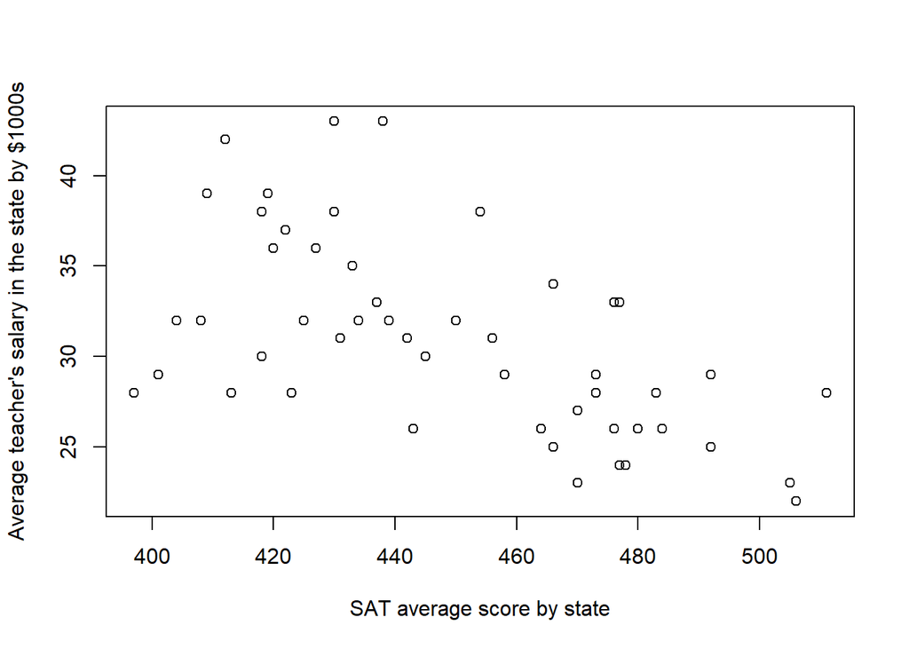

```r
plot(States$SATV,States$pay, xlab = "SAT average score by state", ylab="Average teacher's salary in the state by $1000s")
```

c)

```r
mod7=lm(States$pay~States$SATV)
summary(mod7)
```

```
##
## Call:
## lm(formula = States$pay ~ States$SATV)
##
## Residuals:
##     Min      1Q  Median      3Q     Max
## -7.8391 -3.2860 -0.5626  3.0544 11.0864
##
## Coefficients:
##             Estimate Std. Error t value Pr(>|t|)
## (Intercept) 73.84952    9.18662   8.039 1.67e-10 ***
## States$SATV -0.09574    0.02045  -4.682 2.28e-05 ***
## ---
## Signif. codes:  0 '***' 0.001 '**' 0.01 '*' 0.05 '.' 0.1 ' ' 1
##
## Residual standard error: 4.457 on 49 degrees of freedom
## Multiple R-squared:  0.3091, Adjusted R-squared:  0.295
## F-statistic: 21.92 on 1 and 49 DF,  p-value: 2.284e-05
```

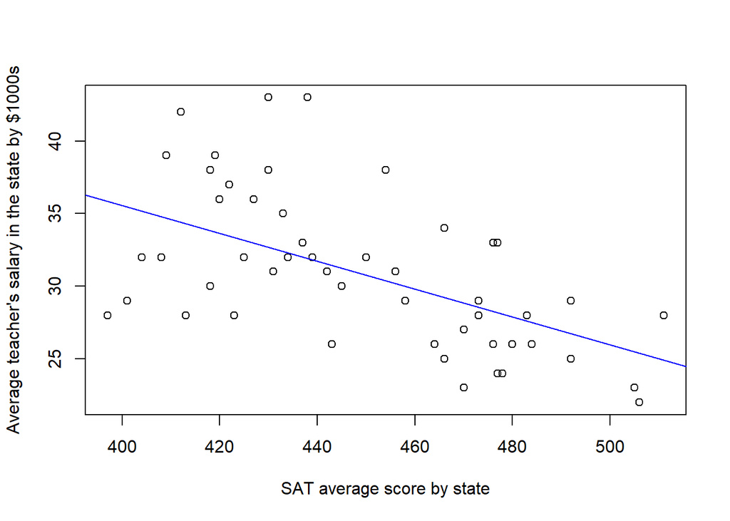

```r
plot(States$SATV,States$pay, xlab = "SAT average score by state", ylab="Average teacher's salary in the state by $1000s")
abline(mod7, col="blue")
```

Based on the linear model, average SAT scores and teacher’s salary are negatively correlated (p=2.28e-5).